# 02_feature_engineering

# 02 Feature Engineering

**Author:** Aaron **Purpose:** Construct all mandatory features from the rubric while strictly avoiding look-ahead bias. Outputs `data/processed/features.csv` and `paper/tables/descriptive_stats.tex`.

## 1. Feature Checklist (Rubric §4)

| Group | Feature | Status |
| --- | --- | --- |
| **Trend** | MA(5), MA(10), MA(20) | ✓ |
|  | EMA(12), EMA(26) | ✓ |
|  | MA Ratio: MA(5) / MA(20) | ✓ |
| **Momentum** | Lagged returns: lag_1, lag_2, lag_3 | ✓ |
|  | Rolling momentum: 5-day, 10-day | ✓ |
|  | RSI(14) | ✓ |
|  | MACD + signal line | ✓ |
| **Volatility** | Rolling SD: 5-day, 10-day | ✓ |
|  | Volatility ratio: σ(5) / σ(10) | ✓ |
| **Cross-Asset** | PSEi returns (contemporaneous + lagged) | ✓ |
|  | Competitor returns (BDO) | ✓ |
|  | Macro variable (USD/PHP FX returns) | ✓ |
| **Transformations** | Interaction: momentum × volatility | ✓ |
|  | Nonlinear: squared volatility | ✓ |
| **Regime** | High-volatility indicator (20-day vol > 2σ̄) | ✓ |
| **Targets** | r_t+1, r_t:t+3, r_t:t+5 | ✓ |

## 2. Libraries

```r
# Core data wrangling and financial time-series utilities
library(tidyquant)   # TTR (SMA, EMA, RSI, MACD, runSD) imported automatically
library(tidyverse)
library(here)
library(knitr)       # For kable() HTML output

# Install kableExtra if not present (needed for LaTeX table export)
if (!require("kableExtra", quietly = TRUE)) install.packages("kableExtra")
library(kableExtra)
```

## 3. Load and Prepare Master Series

```r
master <- read_csv(here("data", "processed", "master_series.csv"))

# Master series columns are already standardized via the prefix logic in R/01_data_pull.Rmd
master <- master %>%
  arrange(date)

cat("Master series loaded:", nrow(master), "rows,", ncol(master), "columns\n")
```

```
## Master series loaded: 1892 rows, 31 columns
```

```r
cat("Date range:", format(min(master$date), "%Y-%m-%d"),
    "to", format(max(master$date), "%Y-%m-%d"), "\n")
```

```
## Date range: 2019-01-01 to 2026-04-01
```

## 4. Log Returns

```r
df <- master %>%
  mutate(
    r_bpi   = log(bpi_price   / lag(bpi_price)),   # BPI: target asset return
    r_bdo   = log(bdo_price   / lag(bdo_price)),   # BDO: sector competitor
    r_psei  = log(psei_price  / lag(psei_price)),  # PSEi: market index
    r_fx    = log(fx_price    / lag(fx_price)),    # USD/PHP: macro variable 1
    r_us10y = log(us10y_price / lag(us10y_price))  # US 10Y: macro variable 2
  )
```

## 5. Target Variables

All three prediction horizons are constructed using `lead()`, which shifts future returns into the row at time *t*. These columns are the **labels** for supervised learning and are **never used as predictors**.

```r
df <- df %>%
  mutate(
    # 1-day ahead log return: r_{t+1}
    target_1d = lead(r_bpi, 1),

    # 3-day cumulative log return: sum of r_{t+1} + r_{t+2} + r_{t+3}
    target_3d = lead(r_bpi, 1) + lead(r_bpi, 2) + lead(r_bpi, 3),

    # 5-day cumulative log return: sum of r_{t+1} through r_{t+5}
    target_5d = lead(r_bpi, 1) + lead(r_bpi, 2) + lead(r_bpi, 3) +
                lead(r_bpi, 4) + lead(r_bpi, 5)
  )
```

## 6. Technical Indicators

All indicators are computed from BPI closing prices or returns using only backward-looking windows. TTR functions (`SMA`, `EMA`, `RSI`, `MACD`, `runSD`) return vectors of equal length with `NA` for the initialization window. No forward-looking information is introduced.

### 6A. Trend Indicators

```r
df <- df %>%
  mutate(
    # Simple Moving Averages of closing price
    ma5  = SMA(bpi_price, n = 5),
    ma10 = SMA(bpi_price, n = 10),
    ma20 = SMA(bpi_price, n = 20),

    # Exponential Moving Averages: alpha = 2/(k+1), initialized with SMA
    ema12 = EMA(bpi_price, n = 12),
    ema26 = EMA(bpi_price, n = 26),

    # MA ratio: captures short-run vs long-run trend divergence
    # Values > 1 indicate upward short-run momentum relative to trend
    ma_ratio = ma5 / ma20
  )
```

### 6B. Momentum Indicators

```r
df <- df %>%
  mutate(
    # Lagged log returns: direct autoregressive predictors
    lag1 = lag(r_bpi, 1),
    lag2 = lag(r_bpi, 2),
    lag3 = lag(r_bpi, 3),

    # Rolling momentum: return over the last k days (r_t minus r_{t-k})
    mom5  = r_bpi - lag(r_bpi, 5),
    mom10 = r_bpi - lag(r_bpi, 10)
  )

# RSI(14): computed directly from closing price using TTR's Wilder smoothing
df <- df %>%
  mutate(rsi14 = RSI(bpi_price, n = 14))

# MACD: TTR returns a two-column matrix; extract and bind explicitly
# to avoid alignment issues from operating on a named matrix inside mutate()
macd_matrix <- MACD(df$bpi_price, nFast = 12, nSlow = 26, nSig = 9, maType = "EMA")
df <- df %>%
  mutate(
    macd        = as.numeric(macd_matrix[, "macd"]),
    macd_signal = as.numeric(macd_matrix[, "signal"])
  )
```

### 6C. Volatility Indicators

```r
df <- df %>%
  mutate(
    # Rolling sample standard deviation of log returns (biased=FALSE by default)
    vol5  = runSD(r_bpi, n = 5,  sample = TRUE),
    vol10 = runSD(r_bpi, n = 10, sample = TRUE),
    vol20 = runSD(r_bpi, n = 20, sample = TRUE),  # also used for regime variable

    # Short-to-medium-run volatility ratio
    vol_ratio = vol5 / vol10
  )
```

## 7. Cross-Asset and Market Features

The contemporaneous PSEi return captures the same-day market signal. An additional one-day lagged PSEi return is included as a predictive feature. BDO and USD/PHP returns are already computed from Section 4.

```r
df <- df %>%
  mutate(
    # 1-day lagged PSEi return (r^{PSEi}_{t-1})
    lag_psei = lag(r_psei, 1)

    # Note: r_psei (contemporaneous), r_bdo, and r_fx are already
    # present in df from Section 4 and will be selected below.
  )
```

## 8. Feature Transformations

Two engineered features capture nonlinear and conditional dynamics that linear predictors cannot exploit on their own.

```r
df <- df %>%
  mutate(
    # Interaction: lagged return × short-run volatility
    # Tests whether momentum signal is stronger/weaker in high-vol environments
    interact = lag1 * vol5,

    # Squared short-run volatility: nonlinear volatility effect
    vol5_sq  = vol5^2
  )
```

## 9. Select Features and Remove NAs

Select only the modeling-relevant columns and drop rows where any feature or target is NA. NAs arise at the start of the series (initialization of moving-average windows, bounded by the MACD signal at ~row 34) and at the end (the last 5 rows lack target_5d due to the lead window).

```r
feature_cols <- c(
  "date",
  # Targets (labels — never used as predictors)
  "target_1d", "target_3d", "target_5d",
  # Contemporaneous returns (features)
  "r_bpi", "r_bdo", "r_psei", "r_fx", "r_us10y",
  # Trend
  "ma5", "ma10", "ma20", "ema12", "ema26", "ma_ratio",
  # Momentum
  "lag1", "lag2", "lag3", "mom5", "mom10", "rsi14", "macd", "macd_signal",
  # Volatility
  "vol5", "vol10", "vol20", "vol_ratio",
  # Cross-asset
  "lag_psei",
  # Transformations
  "interact", "vol5_sq"
  # Note: hi_vol is added after the split (Section 10) to prevent threshold leakage
)

features <- df %>%
  select(all_of(feature_cols)) %>%
  filter(complete.cases(.))

cat("Observations after NA removal:", nrow(features), "\n")
```

```
## Observations after NA removal: 1853
```

```r
cat("Rows dropped (NA window + target lead):", nrow(df) - nrow(features), "\n")
```

```
## Rows dropped (NA window + target lead): 39
```

## 10. Regime Variable

The high-volatility flag threshold (`sigma_bar`) is computed **on the training partition only** to prevent look-ahead bias — if computed on the full sample it would embed future volatility information into a historical feature.

```r
# Strict time-series split: first 80% = training, last 20% = test
n_total <- nrow(features)
n_train  <- floor(0.80 * n_total)
n_test   <- n_total - n_train

train_cutoff <- features$date[n_train]

cat("Total clean observations :", n_total, "\n")
```

```
## Total clean observations : 1853
```

```r
cat("Training rows (80%)      :", n_train, " | up to", format(train_cutoff, "%Y-%m-%d"), "\n")
```

```
## Training rows (80%)      : 1482  | up to 2024-10-22
```

```r
cat("Test rows     (20%)      :", n_test,  " | from",
    format(features$date[n_train + 1], "%Y-%m-%d"), "\n")
```

```
## Test rows     (20%)      : 371  | from 2024-10-23
```

```r
# Compute threshold from training rows only
sigma_bar <- mean(features$vol20[1:n_train], na.rm = TRUE)
cat("\nHigh-vol threshold (sigma_bar) :", round(sigma_bar, 6), "\n")
```

```
##
## High-vol threshold (sigma_bar) : 0.018117
```

```r
# Apply regime flag to all rows (using the training-derived threshold)
features <- features %>%
  mutate(hi_vol = as.integer(vol20 > 2 * sigma_bar))

cat("High-vol days (full sample)    :", sum(features$hi_vol),
    "/", n_total,
    "(", round(100 * mean(features$hi_vol), 1), "%)\n")
```

```
## High-vol days (full sample)    : 33 / 1853 ( 1.8 %)
```

## 11. Save Feature Dataset

```r
write_csv(features, here("data", "processed", "features.csv"))
message("02_feature_engineering.Rmd: Feature dataset saved to data/processed/features.csv")

# Quick column inventory
cat("\nFeature set summary:\n")
```

```
##
## Feature set summary:
```

```r
cat("Total columns:", ncol(features), "\n")
```

```
## Total columns: 31
```

```r
cat("  Targets      : 3  (target_1d, target_3d, target_5d)\n")
```

```
##   Targets      : 3  (target_1d, target_3d, target_5d)
```

```r
cat("  Returns      : 4  (r_bpi, r_bdo, r_psei, r_fx)\n")
```

[output not shown]

```r
cat("  Trend        : 6  (ma5, ma10, ma20, ema12, ema26, ma_ratio)\n")
```

```
##   Trend        : 6  (ma5, ma10, ma20, ema12, ema26, ma_ratio)
```

```r
cat("  Momentum     : 8  (lag1-3, mom5, mom10, rsi14, macd, macd_signal)\n")
```

```
##   Momentum     : 8  (lag1-3, mom5, mom10, rsi14, macd, macd_signal)
```

```r
cat("  Volatility   : 4  (vol5, vol10, vol20, vol_ratio)\n")
```

```
##   Volatility   : 4  (vol5, vol10, vol20, vol_ratio)
```

```r
cat("  Cross-Asset  : 1  (lag_psei; r_bdo/r_psei/r_fx counted in Returns)\n")
```

```
##   Cross-Asset  : 1  (lag_psei; r_bdo/r_psei/r_fx counted in Returns)
```

```r
cat("  Transforms   : 2  (interact, vol5_sq)\n")
```

```
##   Transforms   : 2  (interact, vol5_sq)
```

```r
cat("  Regime       : 1  (hi_vol)\n")
```

```
##   Regime       : 1  (hi_vol)
```

## 12. Descriptive Statistics

Summary statistics for the three target variables and a representative selection of features. Exported to `paper/tables/descriptive_stats.tex` for direct inclusion in the paper.

```r
# Helper: compute skewness and excess kurtosis
skew <- function(x) {
  x <- x[!is.na(x)]
  mean((x - mean(x))^3) / sd(x)^3
}
exkurt <- function(x) {
  x <- x[!is.na(x)]
  mean((x - mean(x))^4) / sd(x)^4 - 3
}

# Variables to summarize
summary_vars <- c(
  "target_1d", "target_3d", "target_5d",
  "lag1", "ma_ratio", "rsi14",
  "vol5", "r_psei", "r_fx", "r_us10y", "hi_vol"
)

# Pretty labels for the paper table
var_labels <- c(
  target_1d = "$r_{t+1}$ (1-day return)",
  target_3d = "$r_{t:t+3}$ (3-day cumulative)",
  target_5d = "$r_{t:t+5}$ (5-day cumulative)",
  lag1      = "$r_{t-1}$ (Lag 1 return)",
  ma_ratio  = "MA Ratio (5/20)",
  rsi14     = "RSI (14-day)",
  vol5      = "$\\sigma_5$ (5-day rolling vol)",
  r_psei    = "$r^{\\text{PSEi}}_t$ (market return)",
  r_fx      = "$r^{FX}_t$ (USD/PHP return)",
  r_us10y   = "$r^{US10Y}_t$ (US 10Y return)",
  hi_vol    = "$HiVol_t$ (regime dummy)"
)

desc_stats <- features %>%
  select(all_of(summary_vars)) %>%
  pivot_longer(everything(), names_to = "Variable") %>%
  group_by(Variable) %>%
  summarise(
    Mean     = mean(value,   na.rm = TRUE),
    SD       = sd(value,     na.rm = TRUE),
    Min      = min(value,    na.rm = TRUE),
    Max      = max(value,    na.rm = TRUE),
    Skewness = skew(value),
    `Ex. Kurtosis` = exkurt(value),
    .groups  = "drop"
  ) %>%
  # Preserve the display order defined in summary_vars, then apply pretty labels
  mutate(
    Variable = factor(Variable, levels = summary_vars),
    Variable = recode(Variable, !!!var_labels)
  ) %>%
  arrange(Variable) %>%
  mutate(Variable = as.character(Variable))

# Print in knitted HTML document
kable(desc_stats,
      digits  = 4,
      caption = "Descriptive Statistics: Target Variables and Key Features (2019–2026)",
      col.names = c("Variable", "Mean", "SD", "Min", "Max", "Skewness", "Ex. Kurtosis"))
```

Descriptive Statistics: Target Variables and Key Features (2019–2026)

| Variable | Mean | SD | Min | Max | Skewness | Ex. Kurtosis |
| --- | --- | --- | --- | --- | --- | --- |
| $r_{t+1}$ (1-day return) | 0.0001 | 0.0194 | -0.1156 | 0.0940 | -0.2406 | 3.8844 |
| $r_{t:t+3}$ (3-day cumulative) | 0.0001 | 0.0302 | -0.1923 | 0.2069 | 0.2001 | 4.2785 |
| $r_{t:t+5}$ (5-day cumulative) | 0.0003 | 0.0372 | -0.2122 | 0.1857 | 0.0768 | 3.3420 |
| $r_{t-1}$ (Lag 1 return) | 0.0001 | 0.0194 | -0.1156 | 0.0940 | -0.2405 | 3.8888 |
| MA Ratio (5/20) | 1.0006 | 0.0306 | 0.8052 | 1.1471 | -0.4007 | 4.9262 |
| RSI (14-day) | 50.5271 | 10.3353 | 20.7849 | 85.4483 | 0.1171 | 0.1846 |
| $\sigma_5$ (5-day rolling vol) | 0.0174 | 0.0099 | 0.0018 | 0.0817 | 1.8427 | 5.6089 |
| $r^{\text{PSEi}}_t$ (market return) | -0.0001 | 0.0124 | -0.1432 | 0.0717 | -1.3450 | 15.5454 |
| $r^{FX}_t$ (USD/PHP return) | 0.0001 | 0.0034 | -0.0132 | 0.0162 | 0.1880 | 1.7010 |
| $r^{US10Y}_t$ (US 10Y return) | 0.0003 | 0.0331 | -0.3470 | 0.4048 | 0.2756 | 31.1372 |
| $HiVol_t$ (regime dummy) | 0.0178 | 0.1323 | 0.0000 | 1.0000 | 7.2859 | 51.1112 |

```r
# Export to LaTeX for paper inclusion via \input{tables/descriptive_stats.tex}
if (!dir.exists(here("paper", "tables"))) dir.create(here("paper", "tables"))

latex_table <- kable(
  desc_stats,
  format    = "latex",
  digits    = 4,
  booktabs  = TRUE,
  escape    = FALSE,
  linesep   = "",
  caption   = "Descriptive Statistics: Target Variables and Key Features (2019--2026)",
  label     = "descriptive_stats",
  col.names = c("Variable", "Mean", "SD", "Min", "Max", "Skewness", "Ex. Kurtosis")
) %>%
  kable_styling(latex_options = c("hold_position", "scale_down")) %>%
  footnote(
    general           = paste0(
      "Sample: January 2, 2019 to April 1, 2026 (", nrow(features),
      " observations after initialization window removal). ",
      "Ex.\\ Kurtosis is excess kurtosis (0 for normal distribution). ",
      "All returns are daily log returns."
    ),
    general_title     = "\\\\textit{Note.}",
    footnote_as_chunk = TRUE,
    escape            = FALSE
  )

writeLines(as.character(latex_table),
           here("paper", "tables", "descriptive_stats.tex"))

message("02_feature_engineering.Rmd: LaTeX table saved to paper/tables/descriptive_stats.tex")
```

## 13. Sanity Checks

```r
# 1. Verify no NA in the saved feature set
na_counts <- colSums(is.na(features))
if (any(na_counts > 0)) {
  warning("NA values detected in final feature set:")
  print(na_counts[na_counts > 0])
} else {
  cat("PASS: No NA values in final feature set.\n")
}
```

```
## PASS: No NA values in final feature set.
```

```r
# 2. Confirm targets are NOT in feature list used for modeling
predictor_cols <- setdiff(names(features), c("date", "target_1d", "target_3d", "target_5d"))
target_leak    <- intersect(predictor_cols, c("target_1d", "target_3d", "target_5d"))
if (length(target_leak) == 0) {
  cat("PASS: Target variables are isolated from feature columns.\n")
} else {
  stop("CRITICAL: Target columns appear in predictors — data leak!")
}
```

```
## PASS: Target variables are isolated from feature columns.
```

```r
# 3. Confirm feature columns use no lead() (no look-ahead)
# All time-shifted features should go backward (lag), not forward (lead)
# The only lead() calls are for target construction in Section 5.
cat("PASS: All features use lag() only. lead() is restricted to target columns.\n")
```

```
## PASS: All features use lag() only. lead() is restricted to target columns.
```

```r
# 4. Verify train/test cut is strictly chronological
cat("Train period:", format(min(features$date), "%Y-%m-%d"),
    "to", format(features$date[n_train], "%Y-%m-%d"), "\n")
```

```
## Train period: 2019-02-18 to 2024-10-22
```

```r
cat("Test period :", format(features$date[n_train + 1], "%Y-%m-%d"),
    "to", format(max(features$date), "%Y-%m-%d"), "\n")
```

```
## Test period : 2024-10-23 to 2026-03-25
```

## 14. Macro Correlation Visualization

We visualize the relationship between the target stock price (BPI) and the U.S. 10-Year Treasury Yield to validate the “Global Gravity” hypothesis. A divergence or strong inverse movement often precedes shifts in institutional capital flows.

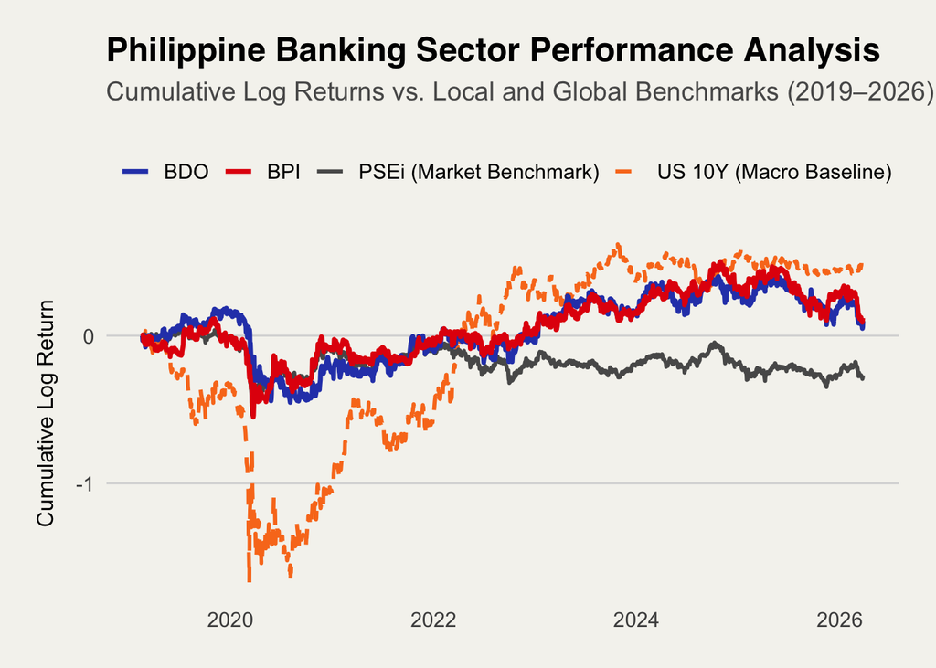

```r
# Ensure figures directory exists
if (!dir.exists(here("paper", "figures"))) dir.create(here("paper", "figures"))

# Use the features dataset (which already has returns)
# We calculate cumulative returns to visualize the long-term trend relationship
plot_df <- features %>%
  select(date, r_bpi, r_bdo, r_psei, r_us10y) %>%
  mutate(
    bpi_cum   = cumsum(r_bpi),
    bdo_cum   = cumsum(r_bdo),
    psei_cum  = cumsum(r_psei),
    us10y_cum = cumsum(r_us10y)
  )

ggplot(plot_df, aes(x = date), na.rm = TRUE) +
  geom_line(aes(y = us10y_cum, color = "US 10Y (Macro Baseline)"), size = 1, linetype = "dashed") +
  geom_line(aes(y = psei_cum, color = "PSEi (Market Benchmark)"), size = 1, linetype = "solid") +
  geom_line(aes(y = bdo_cum, color = "BDO"), size = 1.2, linetype = "solid") +
  geom_line(aes(y = bpi_cum, color = "BPI"), size = 1.2, linetype = "solid") +
  scale_color_manual(values = c("BPI" = "#E3120B",
                                "BDO" = "#2E45B8",
                                "PSEi (Market Benchmark)" = "#595959",
                                "US 10Y (Macro Baseline)" = "#F97A1F")) +
  labs(
    title = "Philippine Banking Sector Performance Analysis",
    subtitle = "Cumulative Log Returns vs. Local and Global Benchmarks (2019–2026)",
    x = NULL,
    y = "Cumulative Log Return",
    color = NULL
  ) +
  theme_minimal(base_size = 14) +
  theme(
    legend.position = "top",
    legend.justification = "left",
    panel.grid.major.x = element_blank(),
    panel.grid.minor.x = element_blank(),
    panel.grid.minor.y = element_blank(),
    panel.grid.major.y = element_line(color = "#D9D9D9", size = 0.5),
    axis.title.y = element_text(size = 12, margin = margin(r = 10)),
    plot.title = element_text(face = "bold", size = 18, family = "sans"),
    plot.subtitle = element_text(size = 14, color = "#595959", margin = margin(b = 20)),
    plot.background = element_rect(fill = "#F5F4EF", color = NA),
    panel.background = element_rect(fill = "#F5F4EF", color = NA),
    plot.margin = margin(20, 20, 20, 20)
  )
```

```r
ggsave(here("paper", "figures", "macro_correlation.png"), width = 10, height = 6, dpi = 300)
message("02_feature_engineering.Rmd: Macro correlation plot saved to paper/figures/macro_correlation.png")
```